# Self-Driving Car Engineer Nanodegree

## Project: Build a Traffic Sign Recognition Classifier

In this notebook, a template is provided for you to implement your functionality in stages which is required to successfully complete this project. If additional code is required that cannot be included in the notebook, be sure that the Python code is successfully imported and included in your submission, if necessary. Sections that begin with **'Implementation'** in the header indicate where you should begin your implementation for your project. Note that some sections of implementation are optional, and will be marked with **'Optional'** in the header.

In addition to implementing code, there will be questions that you must answer which relate to the project and your implementation. Each section where you will answer a question is preceded by a **'Question'** header. Carefully read each question and provide thorough answers in the following text boxes that begin with **'Answer:'**. Your project submission will be evaluated based on your answers to each of the questions and the implementation you provide.

> **Note:** Code and Markdown cells can be executed using the **Shift + Enter** keyboard shortcut. In addition, Markdown cells can be edited by typically double-clicking the cell to enter edit mode.

## Step 0: Load The Data

```python
# Load pickled data
import pickle

# TODO: Fill this in based on where you saved the training and testing data

training_file = "/home/shyam/Work/Shyam/Udacity/train.p"
testing_file = "/home/shyam/Work/Shyam/Udacity/test.p"

with open(training_file, mode='rb') as f:
    train = pickle.load(f)
with open(testing_file, mode='rb') as f:
    test = pickle.load(f)

X_train, y_train = train['features'], train['labels']
X_test, y_test = test['features'], test['labels']
```

## Step 1: Dataset Summary & Exploration

The pickled data is a dictionary with 4 key/value pairs:

- `'features'` is a 4D array containing raw pixel data of the traffic sign images, (num examples, width, height, channels).
- `'labels'` is a 1D array containing the label/class id of the traffic sign. The file `signnames.csv` contains id -> name mappings for each id.
- `'sizes'` is a list containing tuples, (width, height) representing the the original width and height the image.
- `'coords'` is a list containing tuples, (x1, y1, x2, y2) representing coordinates of a bounding box around the sign in the image. **THESE COORDINATES ASSUME THE ORIGINAL IMAGE. THE PICKLED DATA CONTAINS RESIZED VERSIONS (32 by 32) OF THESE IMAGES**

Complete the basic data summary below.

```python
### Replace each question mark with the appropriate value.
import numpy as np

# TODO: Number of training examples
n_train = len(X_train)

# TODO: Number of testing examples.
n_test = len(X_test)

# TODO: What's the shape of an traffic sign image?
image_shape = X_train.shape

# TODO: How many unique classes/labels there are in the dataset.
n_classes = len(np.unique(y_train))

print("Number of training examples =", n_train)
print("Number of testing examples =", n_test)
print("Image data shape =", image_shape)
print("Number of classes =", n_classes)
```

```
Number of training examples = 39209
Number of testing examples = 12630
Image data shape = (39209, 32, 32, 3)
Number of classes = 43
```

Visualize the German Traffic Signs Dataset using the pickled file(s). This is open ended, suggestions include: plotting traffic sign images, plotting the count of each sign, etc.

The [Matplotlib](http://matplotlib.org/) [examples](http://matplotlib.org/examples/index.html) and [gallery](http://matplotlib.org/gallery.html) pages are a great resource for doing visualizations in Python.

**NOTE:** It's recommended you start with something simple first. If you wish to do more, come back to it after you've completed the rest of the sections.

```python
### Data exploration visualization goes here.
### Feel free to use as many code cells as needed.
import matplotlib.pyplot as plt
import numpy as np
# Visualizations will be shown in the notebook.
%matplotlib inline

#Helper function for visualizing data set distribution
def plotHist(set1, bins, title=''):
    dist1 = plt.hist(set1, bins)
    plt.xlabel('classes')
    plt.ylabel('examples')
    plt.title(title)
    plt.show()

    return dist1

def plot2Hist(set1, set2, bins, title1='', title2=''):
    dist1 = plt.hist(set1, bins, alpha=0.5, label=title1)
    dist2 = plt.hist(set2, bins, alpha=0.5, label=title2)
    plt.xlabel('classes')
    plt.ylabel('examples')
    plt.legend(loc='upper right')
    plt.show()

    return dist1, dist2

#Helper function to display a scatter plot
def plotScatter(set1, set2, bins, title1='', title2='', color1='blue', color2='green'):

    fig, ax = plt.subplots()
    ax.scatter(set1, set2)
    ax.set_xlabel(title1)
    ax.set_ylabel(title2)

    for i, txt in enumerate(bins):
        ax.annotate(txt, (set1[i], set2[i]))

    plt.show()

#Helper function to plot one image
def plotImage(data, label):
    plt.imshow(data)
    plt.title('Class ID: ' + str(label))
    plt.show()

#Helper function to plot an array of images
def plotImages(data, label):
    cols = 4
    rows = np.ceil(len(data)/4)

    fig = plt.figure(figsize=(20, 10))

    plt.subplots_adjust(0.1, 0.1, 0.9, 0.9, 0.5, 0.5)
    for i in range(len(data)):
        plt.subplot(rows, cols, i+1)
        plt.axis('off')
        plt.imshow(data[i])
        plt.title(str(label[i]))

    plt.show()

#Helper function to plot a curve
def plotCurve(data, title='', xaxis='', yaxis='', yrange=[0., 10.]):
    plt.plot(data)
    plt.xlabel(xaxis)
    plt.ylabel(yaxis)
    plt.title(title)
    plt.ylim(yrange)
    plt.show()

#Helper function to plot log curve
def plotLogCurve(data, title='', xaxis='', yaxis=''):
    plt.plot(data)
    plt.xlabel(xaxis)
    plt.ylabel(yaxis)
    plt.title(title)
    plt.yscale('log')
    plt.show()
```

Read and Display reference traffic signs icons stored in tsr_icons folder. This is just for diplay purpose.

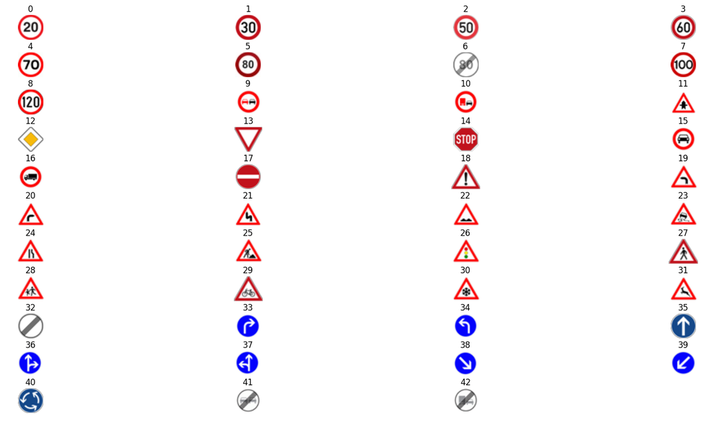

```python
import numpy as np
import matplotlib.pyplot as plt
import matplotlib.image as mpimg
import cv2

file_name = './tsr_icons/'
icon_list  = []
for i in range(n_classes):
    full_path = file_name + str(i) + '.png'
    img = mpimg.imread(full_path)
    icon_list.append(img)

icon_set = np.array(icon_list)

plotImages(icon_set, np.arange(n_classes))
```

View Train set distribution

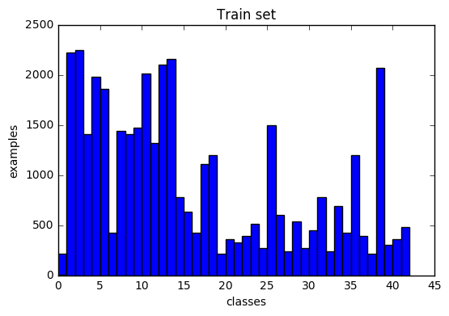

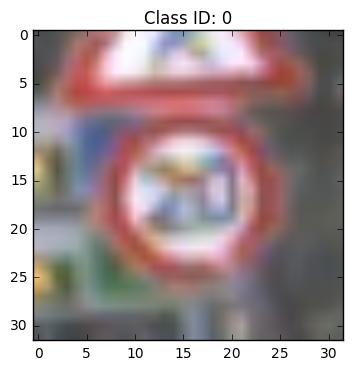

```python
plotHist(y_train, range(n_classes), 'Train set')
plotImage(X_train[0], str(y_train[0]))
```

## Step 2: Design and Test a Model Architecture

Design and implement a deep learning model that learns to recognize traffic signs. Train and test your model on the [German Traffic Sign Dataset](http://benchmark.ini.rub.de/?section=gtsrb&subsection=dataset).

There are various aspects to consider when thinking about this problem:

- Neural network architecture
- Play around preprocessing techniques (normalization, rgb to grayscale, etc)
- Number of examples per label (some have more than others).
- Generate fake data.

Here is an example of a [published baseline model on this problem](http://yann.lecun.com/exdb/publis/pdf/sermanet-ijcnn-11.pdf). It's not required to be familiar with the approach used in the paper but, it's good practice to try to read papers like these.

**NOTE:** The LeNet-5 implementation shown in the classroom at the end of the CNN lesson is a solid starting point. You'll have to change the number of classes and possibly the preprocessing, but aside from that it's plug and play!

### Implementation

Use the code cell (or multiple code cells, if necessary) to implement the first step of your project. Once you have completed your implementation and are satisfied with the results, be sure to thoroughly answer the questions that follow.

```python
### Preprocess the data here.
### Feel free to use as many code cells as needed.

#Helper function to adjust the range of inputs from 0-255 to -0.5 to 0.5
def normInput(data):
    output = ((data * 1.0) - 128.) * 1/128.

    return output
```

### Question 1

*Describe how you preprocessed the data. Why did you choose that technique?*

**Answer:**

Although I started the project by using the normInput function, I learned from Tensorflow.org that we could apply image distortions on the fly while creating batches. This is a very powerful feature of Tensorflow especially while working with large data sets. So, I've skipped the preprocess stage proceed to split the train set as 90% Train set and 10% Validation set

```python
### Generate additional data (OPTIONAL!)
### and split the data into training/validation/testing sets here.
### Feel free to use as many code cells as needed.

# Helper function accepts array of images and labels and returns train set and validation
# based on set_aside value provided by the user. Eg. If set_aside is 0.2, then 20% of the
# input is set aside as validation set
def create_train_valid_set(data_set, data_labels, data_dist, set_aside):

    num_classes = len(data_dist)

    valid_samples = []
    train_samples = []

    valid_labels = []
    train_labels = []

    offset = 0
    valid_len = int(data_dist[0] * set_aside)
    train_len = int(data_dist[0] * (1 - set_aside))

    start = offset
    end = valid_len

    valid_samples = data_set[start:end]
    train_samples = data_set[end:(end + train_len)]

    valid_labels = data_labels[start:end]
    train_labels = data_labels[end:(end + train_len)]

    offset += (train_len + valid_len)

    for i in range(1, num_classes):
        valid_len = int(np.floor(data_dist[i] * set_aside))
        train_len = int(np.ceil(data_dist[i] * (1 - set_aside)))

        start = offset
        end   = offset + valid_len

        valid_samples = np.concatenate((valid_samples, data_set[start:end]), axis=0)
        train_samples = np.concatenate((train_samples, data_set[end:(end + train_len)]), axis=0)

        valid_labels = np.concatenate((valid_labels, data_labels[start:end]), axis=0)
        train_labels = np.concatenate((train_labels, data_labels[end:(end + train_len)]), axis=0)

        offset += (train_len + valid_len)

    return train_samples, train_labels, valid_samples, valid_labels
```

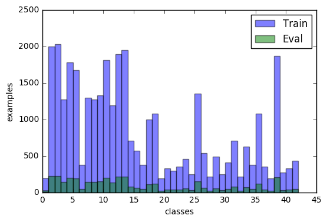

```
Training Distribution
[  189.  1998.  2025.  1269.  1782.  1674.   378.  1296.  1269.  1323.
  1809.  1188.  1890.  1944.   702.   567.   378.   999.  1080.   189.
   324.   297.   351.   459.   243.  1350.   540.   216.   486.   243.
   405.   702.   216.   621.   378.  1080.   351.   189.  1863.   270.
   324.   432.]
[ 0  1  2  3  4  5  6  7  8  9 10 11 12 13 14 15 16 17 18 19 20 21 22 23 24
 25 26 27 28 29 30 31 32 33 34 35 36 37 38 39 40 41 42]
Validation Distribution
[  21.  222.  225.  141.  198.  186.   42.  144.  141.  147.  201.  132.
  210.  216.   78.   63.   42.  111.  120.   21.   36.   33.   39.   51.
   27.  150.   60.   24.   54.   27.   45.   78.   24.   68.   42.  120.
   39.   21.  207.   30.   36.   48.]
[ 0  1  2  3  4  5  6  7  8  9 10 11 12 13 14 15 16 17 18 19 20 21 22 23 24
 25 26 27 28 29 30 31 32 33 34 35 36 37 38 39 40 41 42]
```

```python
#Create Training and Validation set from Full data set
data_dist = np.bincount(y_train)

train_set, train_labels, valid_set, valid_labels = create_train_valid_set(X_train, y_train, data_dist, 0.1)

train_dist, valid_dist = plot2Hist(train_labels, valid_labels, range(n_classes), 'Train', 'Eval')

print('Training Distribution')
print(train_dist[0])
print(train_dist[1])

print('Validation Distribution')
print(valid_dist[0])
print(valid_dist[1])
```

### Question 2

*Describe how you set up the training, validation and testing data for your model. **Optional**: If you generated additional data, how did you generate the data? Why did you generate the data? What are the differences in the new dataset (with generated data) from the original dataset?*

**Answer:**

The given data set is split as 90% training set and 10% validation set from each class.

For Eg. In the input set if class 0 has 100 images and class 1 has 200 images, then training set will have 90 images in class 0 and 180 images in class 1 and validation set will have 10 images from class 0 and 20 imgages from class 1.

At this stage additional data is not generated. Later down the code, Tensorflow Queues are used to randomly generate the inputs with image distortions applied on the fly.

```python
import tensorflow as tf
```

```python
from sklearn.utils import shuffle

#Shuffle the newly formed train, validation and also the test set
train_set, train_labels = shuffle(train_set, train_labels)
valid_set, valid_labels = shuffle(valid_set, valid_labels)
test_set, test_labels = shuffle(X_test, y_test)

print(train_labels)
print(valid_labels)
print(test_labels)
```

```
[31 17 34 ..., 40  1 17]
[14 10  3 ...,  4  1  4]
[ 1  4 42 ..., 13 12 38]
```

From Tensorflow.org I learned that Queues can be used to batch inputs and apply image distortions on the fly. This is a very powerful feature especially when dealing with large datasets. There are couple of ways to create Queues, in this project I've used **tf.train.string_input_producer(...)** to open a queue start supplying batches from a protobuf.

The newly formed and shuffled training, validation and also the test set is serialized by constructing a proto buf object and written to its respective files. Each protobuf object consist of lable and corresponding image which is serialized to string and written to file. The TFRecordeWriter class is used to write the serialized data.

```python
#Helper function to write label as int64. Allowed formats are int64, float and byte
def _int64_feature(value):
    return tf.train.Feature(int64_list=tf.train.Int64List(value=[value]))

#Helper function to write image as an array of bytes
def _bytes_feature(value):
    return tf.train.Feature(bytes_list=tf.train.BytesList(value=[value]))

#Helper function to serialize data given the file name, image array, label array and length of input
def _serialize_data(file_name, features_set, labels_set, length):
    writer = tf.python_io.TFRecordWriter(file_name)
    print('Num records', length)
    for example_idx in range(length):
        features = features_set[example_idx]
        label = labels_set[example_idx]

        # construct the Example proto boject
        example = tf.train.Example(
            # Example contains a Features proto object
            features=tf.train.Features(
              # Features contains a map of string to Feature proto objects
              feature={
                # A Feature contains one of either a int64_list,
                # float_list, or bytes_list
                'label': _int64_feature(int(label)),
                'image': _bytes_feature(bytes(features)),
        }))
        # use the proto object to serialize the example to a string
        serialized = example.SerializeToString()
        # write the serialized object to disk
        writer.write(serialized)
```

Create 3 separate files,

gts.train - Consist of serialized image and label objects used for training (90% of the total train set) gts.valid - Consist of serialized image and label objects used for validation (10% of the total train set) gts.test - Consist of serialized image and label objects used for testing

```python
print('Writing gts.train protobuf...')
_serialize_data('gts.train', train_set, train_labels, len(train_set))
print('Done')

print('====================================')

print('Writing gts.valid protobuf...')
_serialize_data('gts.valid', valid_set, valid_labels, len(valid_set))
print('Done')

print('====================================')

print('Writing gts.test protobuf...')
_serialize_data('gts.test', test_set, test_labels, len(test_set))
print('Done')
```

```
Writing gts.train protobuf...
Num records 35289
Done
====================================
Writing gts.valid protobuf...
Num records 3920
Done
====================================
Writing gts.test protobuf...
Num records 12630
Done
```

```python
#Helper function to deserialize one protobuf object as 1-image and 1-lable entry
def _read_one_example(filename):
    # first construct a queue containing a list of filenames.
    filename_queue = tf.train.string_input_producer([filename],
                                                    num_epochs=None)
    reader = tf.TFRecordReader()
    # One can read a single serialized example from a filename
    # serialized_example is a Tensor of type string.
    _, serialized_example = reader.read(filename_queue)
    # The serialized example is converted back to actual values.
    # One needs to describe the format of the objects to be returned
    features = tf.parse_single_example(
        serialized_example,
        features={
            'label': tf.FixedLenFeature([], tf.int64),
            'image': tf.FixedLenFeature([], tf.string)
        })
    #Since the image written is raw, read back in raw format
    image = tf.decode_raw(features['image'], tf.uint8)
    image = tf.reshape(image, [32, 32, 3])
    label = tf.cast(features['label'], tf.int32)

    return image, label
```

```python
#Helper function to create a batch of image an labels. Used from cifar10 example in Tensorflow git hub
def _generate_image_and_label_batch(image, label, min_queue_examples, batch_size, shuffle=True):
    """Construct a queued batch of images and labels.
    Args:
      image: 3-D Tensor of [height, width, 3] of type.float32.
      label: 1-D Tensor of type.int32
      min_queue_examples: int32, minimum number of samples to retain
        in the queue that provides of batches of examples.
      batch_size: Number of images per batch.
    Returns:
      images: Images. 4D tensor of [batch_size, height, width, 3] size.
      labels: Labels. 1D tensor of [batch_size] size.
    """
    # Create a queue that shuffles the examples, and then
    # read 'batch_size' images + labels from the example queue.
    num_preprocess_threads = 16
    if(shuffle==True):
        images, label_batch = tf.train.shuffle_batch(
                                [image, label],
                                batch_size=batch_size,
                                num_threads=num_preprocess_threads,
                                capacity=min_queue_examples + 3 * batch_size,
                                min_after_dequeue=min_queue_examples)
    else:
        images, label_batch = tf.train.batch(
                                [image, label],
                                batch_size=batch_size,
                                num_threads=num_preprocess_threads,
                                capacity=min_queue_examples + 3 * batch_size)

    return images, tf.reshape(label_batch, [batch_size])
```

```python
#Helper function to apply image distortions on the fly during training
def distorted_inputs(file_name, batch_size, num_examples, shuffle=True):
    """Construct distorted input for GTS training using the Reader ops.
    """
    #Read one example
    read_input, read_labels = _read_one_example(file_name)
    #Cast the 8bit input image to float32
    distorted_image = tf.cast(read_input, tf.float32)

    #Convert the input from 32x32x3 to 30x30x3 and randomly crop
    distorted_image = tf.random_crop(distorted_image, [30, 30, 3])

    #This distortion was bringing down the validation set accuracy for some reason.
    #Currently disabled during training
    #distorted_image = tf.image.random_flip_left_right(distorted_image)

    #Randomly adjust brightness of the image
    distorted_image = tf.image.random_brightness(distorted_image, max_delta=63)

    #Randomly adjust contrast of the image
    distorted_image = tf.image.random_contrast(distorted_image, lower=0.2, upper=1.8)

    # Normalize the image by subtracting the mean and divided by the variance of the pixels.
    float_image = tf.image.per_image_standardization(distorted_image)

    # Ensure that the random shuffling has good mixing properties.
    min_fraction_of_examples_in_queue = 0.4
    min_queue_examples = int(num_examples * min_fraction_of_examples_in_queue)
    print ('Filling queue with %d GTS images before starting to train.' 'This will take a few minutes.' % min_queue_examples)

    # Generate a batch of images and labels by building up a queue of examples.
    return _generate_image_and_label_batch(float_image, read_labels, min_queue_examples, batch_size, shuffle)
```

```python
#Helper function read images during validation and testing
def read_inputs(file_name, batch_size, num_examples, shuffle=False):
    """Construct distorted input for GTS training using the Reader ops.
    """

    #Read one example
    read_input, read_labels = _read_one_example(file_name)
    #Cast the 8bit input image to float32
    reshaped_image = tf.cast(read_input, tf.float32)

    #Here we only need to crop the image to 30x30x3
    reshaped_image = tf.image.resize_image_with_crop_or_pad(reshaped_image, 30, 30)

    # Subtract off the mean and divide by the variance of the pixels.
    float_image = tf.image.per_image_standardization(reshaped_image)

    # Ensure that the random shuffling has good mixing properties.
    min_fraction_of_examples_in_queue = 0.4
    min_queue_examples = int(num_examples * min_fraction_of_examples_in_queue)
    print ('Filling queue with %d GTS images before starting to validate.' 'This will take a few minutes.' % min_queue_examples)

    # Generate a batch of images and labels by building up a queue of examples.
    return _generate_image_and_label_batch(float_image, read_labels, min_queue_examples, batch_size, shuffle)
```

```python
### Define your architecture here.
### Feel free to use as many code cells as needed.
from tensorflow.contrib.layers import flatten

#coolNet is the result of multiple iterations of modifications to LeNet used for classifying MINST.
def coolNet(x, keep_prob):
    # Arguments used for tf.truncated_normal, randomly defines variables for the weights and biases for each layer
    mu = 0
    sigma = 0.1

    # Layer 1: Convolutional. Input = 30x30x3. Output = 28x28x16.
    conv1_W = tf.Variable(tf.truncated_normal(shape=(3, 3, 3, 16), mean = mu, stddev = sigma), name='conv1_W')
    conv1_b = tf.Variable(tf.zeros(16), name='conv1_b')
    conv1   = tf.nn.conv2d(x, conv1_W, strides=[1, 1, 1, 1], padding='VALID') + conv1_b

    # Apply local response normalization like the one used in AlexNet (and CIFAR10 tensorflow example)
    # I am applying it before ReLU as it shifts the logits in range for ReLU
    norm1 = tf.nn.lrn(conv1, 4, bias=1.0, alpha=0.001 / 9.0, beta=0.75, name='norm1')

    # Apply ReLU Activation.
    conv1 = tf.nn.relu(norm1)

    # Pooling. Input = 28x28x16. Output = 14x14x16.
    conv1 = tf.nn.max_pool(conv1, ksize=[1, 2, 2, 1], strides=[1, 2, 2, 1], padding='VALID')

    # Layer 2: Convolutional. Input = 14x14x16, Output = 12x12x32.
    conv2_W = tf.Variable(tf.truncated_normal(shape=(3, 3, 16, 32), mean = mu, stddev = sigma), name='conv2_W')
    conv2_b = tf.Variable(tf.zeros(32), name='conv2_b')
    conv2   = tf.nn.conv2d(conv1, conv2_W, strides=[1, 1, 1, 1], padding='VALID') + conv2_b

    # Apply local response normalization
    norm2 = tf.nn.lrn(conv2, 4, bias=1.0, alpha=0.001 / 9.0, beta=0.75, name='norm2')

    # Apply ReLU Activation.
    conv2 = tf.nn.relu(norm2)

    # Pooling. Input = 12x12x32. Output = 6x6x32.
    conv2 = tf.nn.max_pool(conv2, ksize=[1, 2, 2, 1], strides=[1, 2, 2, 1], padding='VALID')

    # Layer 3: Convolutional. Input = 6x6x32, Output = 4x4x64.
    conv3_W = tf.Variable(tf.truncated_normal(shape=(3, 3, 32, 64), mean = mu, stddev = sigma), name='conv3_W')
    conv3_b = tf.Variable(tf.zeros(64), name='conv3_b')
    conv3   = tf.nn.conv2d(conv2, conv3_W, strides=[1, 1, 1, 1], padding='VALID') + conv3_b

    # Apply local response normalization
    norm3 = tf.nn.lrn(conv3, 4, bias=1.0, alpha=0.001 / 9.0, beta=0.75, name='norm3')

    # Apply ReLU Activation.
    conv3 = tf.nn.relu(norm3)

    # Flatten. Input = 4x4x64. Output = 1024.
    fc0   = flatten(conv3)

    # Layer 4: Fully Connected. Input = 1024. Output = 512.
    fc1_W = tf.Variable(tf.truncated_normal(shape=(1024, 512), mean = mu, stddev = sigma), name='fc1_W')
    fc1_b = tf.Variable(tf.zeros(512), name='fc1_b')
    fc1   = tf.matmul(fc0, fc1_W) + fc1_b

    # ReLU Activation.
    fc1    = tf.nn.relu(fc1)

    # Layer 5: Fully Connected. Input = 512. Output = 256.
    fc2_W  = tf.Variable(tf.truncated_normal(shape=(512, 256), mean = mu, stddev = sigma), name='fc2_W')
    fc2_b  = tf.Variable(tf.zeros(256), name='fc2_b')
    fc2    = tf.matmul(fc1, fc2_W) + fc2_b

    # ReLU Activation.
    fc2    = tf.nn.relu(fc2)

    # Apply Dropout layer in the hidden layers
    fc2_d  = tf.nn.dropout(fc2, keep_prob)

    # Layer 6: Fully Connected. Input = 256. Output = 43.
    fc3_W  = tf.Variable(tf.truncated_normal(shape=(256, 43), mean = mu, stddev = sigma), name='fc3_W')
    fc3_b  = tf.Variable(tf.zeros(43), name='fc3_b')
    logits = tf.matmul(fc2_d, fc3_W) + fc3_b

    return logits
```

### Question 3

*What does your final architecture look like? (Type of model, layers, sizes, connectivity, etc.) For reference on how to build a deep neural network using TensorFlow, see Deep Neural Network in TensorFlow from the classroom.*

# CoolNet solution

[figure not shown]

**Answer:**

Network architecture of coolNet is derrived from LeNet architecture used for MINST digit classification. This was a result of mupltiple iterations of tweaking while training and validation.

Layer 1 Convolution - 3x3 kernels- 3ip/ch:16op/ch, input size: 30x30x3 - Output size: 28x28x16 Normalization - LRN Activation - ReLU Pooling - Max - 2x2:stride 2, input size: 28x28x16 - Output size: 14x14x16

Layer 2 Convolution - 3x3 kernels- 16ip/ch:32op/ch, input size: 14x14x16 - Output size: 12x12x32 Normalization - LRN Activation - ReLU Pooling - Max - 2x2:stride 2, input size: 12x12x32 - Output size: 6x6x32

Layer 3 Convolution - 3x3 kernels- 32ip/ch:64op/ch, input size: 6x6x32 - Output size: 4x4x64 Normalization - LRN Activation - ReLU Flatten - input size: 4x4x64 - Output size - 1024

Layer 4 Fully Connected - Input: 1024, Output: 512, Weights: 1024x512, Bias:512 Activation: ReLU

Layer 5 Fully Connected - Input: 512, Output: 256, Weights: 512x256, Bias:256 Activation: ReLU Dropout: Set at 50% during training, 100% while testing

Layer 6 Fully Connected - Input: 256, Output: 43, Weights: 256x43, Bias:43

===================================

By making convoluion kernel sizes as 3x3 instead of 5x5 (as in LeNet) I was able to introduce a 3rd convolution layer, this helped boot the validation accuracy by almost 3-4%

A normalization is applied after every convolution layer. This boosted the validation accuracy by 2%. More powerfull techniques such as batch normalization will provide higher benefits but I somehow could not get it to work.

Pooling layer is actually pretty brutal by picking only the max response in a 2x2 neighborhood and downsizing the inputs by half in both horizal and vertial directions. Its needed to reduce the feature vector lenght which gets fed to the fully connected layer for classification.

Dropout layer is applied only in "Layer5" and kept at 50%. Multiple experiments were tried by setting keep_pro to 75%, applying dropout in Layer4 etc.

```python
### Train your model here.
### Feel free to use as many code cells as needed.

EPOCHS = 30

#Decay the learning rate at 1/3rd the number of epochs
NUM_EPOCHS_PER_DECAY = EPOCHS / 3

#Set batch size as 256. Tried sizes are 128 and 256
BATCH_SIZE = 256

#Set initial learning rate to 0.001. Tried values are 0.1, 0.01, 0.001
init_rate = 0.001

#Decay by 1/10th of initial learning rate after every 1/3rd of EPOCHS. Tried values 0.96, 0.1
decay_factor = 0.1

# Number of batches in an EPOCH is total size / batch size
num_batches_per_epoch = len(train_set)/ BATCH_SIZE

#Total number of iterations per decay
decay_steps = int(num_batches_per_epoch * NUM_EPOCHS_PER_DECAY)

#Create a place holder for setting dropout keep probability, 50% during training, 100% while testing
keep_prob = tf.placeholder(tf.float32)

#Create a global_step vaiable to keep track of number of iterations. This will help change the decay rate
global_step = tf.Variable(0, trainable=False, name='global_step')

#Create place holders for input and labels. The input queues will feed the inputs
x = tf.placeholder(tf.float32, (None, 30, 30, 3))
y = tf.placeholder(tf.int32, (None))

#Supply the input and keep probability to the network to return logits
logits = coolNet(x, keep_prob)

#One hot encode the lables to compute cross entropy loss
one_hot_y = tf.one_hot(y, 43)

#Compute cross entropy loss
cross_entropy = tf.nn.softmax_cross_entropy_with_logits(logits, one_hot_y)
loss_op = tf.reduce_mean(cross_entropy)

#Use an exponential decay learning rate. Decay the value from init_rate by decay_factor
lr_rate = tf.train.exponential_decay(init_rate, global_step, decay_steps, decay_factor, staircase=True)

#Apply ADAM Optimizer. Tried optimizers are GradientDescent, ADAM
optimizer = tf.train.AdamOptimizer(learning_rate = lr_rate)
train_op = optimizer.minimize(loss_op, global_step=global_step)

#Compute accuracy for validation and test sets
correct_prediction = tf.equal(tf.argmax(logits, 1), tf.argmax(one_hot_y, 1))
accuracy_op = tf.reduce_mean(tf.cast(correct_prediction, tf.float32))
```

```python
#Open a queue of training images. This que will stream inputs from protobuf and provide a batch of inputs per step
images, labels = distorted_inputs('gts.train', BATCH_SIZE, len(train_set))

train_itrs = int(np.ceil(len(train_set)/BATCH_SIZE))
loss_arr = [train_itrs * EPOCHS]
lr_arr = [EPOCHS]

#Get a handle to Saver to save the trained model
saver = tf.train.Saver()

print("Training...")
with tf.Session() as sess:
    #Initialze all global variables, weights, bias, global step etc.
    sess.run(tf.global_variables_initializer())

    # initialize the queue threads to batching data
    coord = tf.train.Coordinator()
    threads = tf.train.start_queue_runners(coord=coord)

    for n in range(EPOCHS):
        print("EPOCH {} ...".format(n+1))
        for i in range(train_itrs):
            #Supply each batch using feed dictionary method
            batch_x, batch_y = sess.run([images, labels])
            _, loss = sess.run([train_op, loss_op], feed_dict={x:batch_x, y:batch_y, keep_prob: 0.5})
            #Increment global step counter to change learning rate
            global_step = global_step + 1
            #Capture loss at each step
            loss_arr.append(loss)

        #Capture learning rate change after each epoch
        lr_arr.append(sess.run(lr_rate))

    #Capture the model when training is complete
    saver.save(sess, './lenet')
    print("Model saved")

    # stop our queue threads and properly close the session
    coord.request_stop()
    coord.join(threads)
    sess.close()
```

```
Filling queue with 14115 GTS images before starting to train.This will take a few minutes.
Training...
EPOCH 1 ...
EPOCH 2 ...
EPOCH 3 ...
EPOCH 4 ...
EPOCH 5 ...
EPOCH 6 ...
EPOCH 7 ...
EPOCH 8 ...
EPOCH 9 ...
EPOCH 10 ...
EPOCH 11 ...
EPOCH 12 ...
EPOCH 13 ...
EPOCH 14 ...
EPOCH 15 ...
EPOCH 16 ...
EPOCH 17 ...
EPOCH 18 ...
EPOCH 19 ...
EPOCH 20 ...
EPOCH 21 ...
EPOCH 22 ...
EPOCH 23 ...
EPOCH 24 ...
EPOCH 25 ...
EPOCH 26 ...
EPOCH 27 ...
EPOCH 28 ...
EPOCH 29 ...
EPOCH 30 ...
Model saved
```

Plot the loss curve and learning rate curves

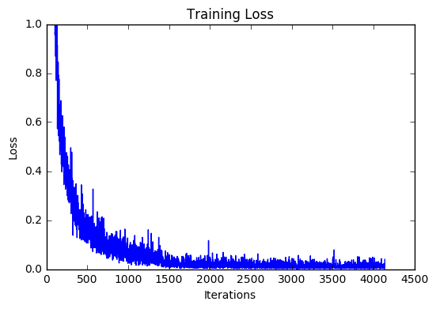

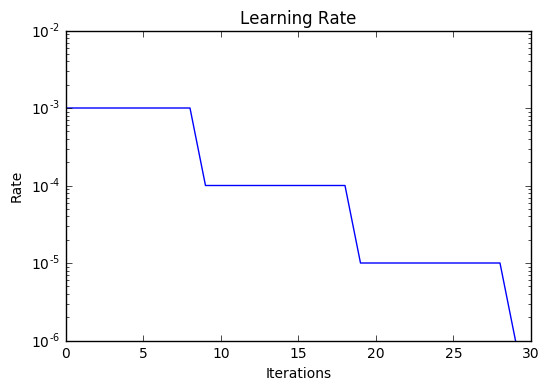

```python
plotCurve(loss_arr[1:], 'Training Loss', 'Iterations', 'Loss', [0., 1.])
plotLogCurve(lr_arr[1:], 'Learning Rate', 'Iterations', 'Rate')
```

Once training is complete, performance inference on the validation set once after N epochs

```python
#Open a que to batch inputs for validation
images, labels = read_inputs('gts.valid', BATCH_SIZE, len(valid_set))

#Get a handle to Saver() to resotre the trainied model
saver = tf.train.Saver()

valid_itrs = int(len(valid_set)/BATCH_SIZE)
print("Running Validation Set...")

with tf.Session() as sess:
    ckpt = tf.train.get_checkpoint_state('.')
    if ckpt and ckpt.model_checkpoint_path:
        # Restores from checkpoint
        print ('Model found!')
        saver.restore(sess, ckpt.model_checkpoint_path)
        print ('Model loaded!')
    else:
        print ('No checkpoint file found!')

    # initialize the queue threads to batching validation set
    coord = tf.train.Coordinator()
    threads = tf.train.start_queue_runners(coord=coord)

    total_accuracy = 0
    total_size = 0
    for offset in range(valid_itrs):
        batch_x, batch_y = sess.run([images, labels])
        #Run inference and comptue the accuracy. Remember to set keep probability at 100%
        accuracy = sess.run(accuracy_op, feed_dict={x:batch_x, y:batch_y, keep_prob: 1.0})
        #Accumulate the accuracy per iteration
        total_accuracy += (accuracy * len(batch_x))
        total_size += len(batch_x)

    print('Validation Accuracy: ', total_accuracy / total_size)

    # stop our queue threads and properly close the session
    coord.request_stop()
    coord.join(threads)
    sess.close()
```

```
Filling queue with 1568 GTS images before starting to validate.This will take a few minutes.
Running Validation Set...
Model found!
Model loaded!
Validation Accuracy:  0.961979166667
```

```python
#Open a que to batch inputs for testing
images, labels = read_inputs('gts.test', BATCH_SIZE, len(test_set))

#Get a handle to Saver() to resotre the trainied model
saver = tf.train.Saver()

test_itrs = int(len(test_set)/BATCH_SIZE)
print("Running Test set...")

with tf.Session() as sess:
    ckpt = tf.train.get_checkpoint_state('.')
    if ckpt and ckpt.model_checkpoint_path:
        # Restores from checkpoint
        print ('Model found!')
        saver.restore(sess, ckpt.model_checkpoint_path)
        print ('Model loaded!')
    else:
        print ('No checkpoint file found!')

    # initialize the queue threads to start batching test data
    coord = tf.train.Coordinator()
    threads = tf.train.start_queue_runners(coord=coord)

    total_accuracy = 0
    total_size = 0
    for offset in range(test_itrs):
        batch_x, batch_y = sess.run([images, labels])
        accuracy = sess.run(accuracy_op, feed_dict={x:batch_x, y:batch_y, keep_prob: 1.0})
        total_accuracy += (accuracy * len(batch_x))
        total_size += len(batch_x)

    print('Test Accuracy: ', total_accuracy / len(test_set))

    # stop our queue threads and properly close the session
    coord.request_stop()
    coord.join(threads)
    sess.close()
```

```
Filling queue with 5052 GTS images before starting to validate.This will take a few minutes.
Running Test set...
Model found!
Model loaded!
Test Accuracy:  0.963262074426
```

### Question 4

*How did you train your model? (Type of optimizer, batch size, epochs, hyperparameters, etc.)*

**Answer:**

**Choice of Optimizer**

I chose ADAM optimizer over GradientDescent as it uses momentum of previous gradients to reach a minimum faster than Gradient descent appraoch. SGD approach takes longer time to reach a saddle point, af few hunder iterations compared to ADAM approach which reaches a minimum right after a handful of iterations.

**Choice of Batch Size**

Batch sizes tried were 128 and 256 Larger batch size is better and yeilds better validation accuracy (1% to 2%) But its limited to available GPU memory size. 256 worked like a charm.

**Choice of Epochs**

**Choice of learning rate**

Learning rate tried were 0.1, 0.01, 0.001, 0.0001 An init value of 0.1 is very damaging which gradients bounding off and network not converging at all. Its a too high value to start with. 0.01 is better but needs more training time. 0.001 was a good starting point with nice step wise exponential decay after every 1/3rd total epochs

**Choice of rate decay**

Rate decay options were 0.96 and 0.1 By setting decay to 0.96, the runtime between iterations is faster. This because the learning rate is only marginally reduced from initial to initial * 0.96 Setting decay rate to 1/10th (0.1) will increase runtime after every decay step but is a good way to get out of one saddle point as the update steps are smaller

**Choice of keep probability for dropout**

Options tried were 1.0, 0.75 and 0.5 Between 1.0 (Keep all connections) to 0.5 (Keep just 50% of connections) I noticed an improvement of (1.5% to 2%)

### Question 5

*What approach did you take in coming up with a solution to this problem? It may have been a process of trial and error, in which case, outline the steps you took to get to the final solution and why you chose those steps. Perhaps your solution involved an already well known implementation or architecture. In this case, discuss why you think this is suitable for the current problem.*

**Answer:**

I spent most of the time trying to implement the solution using Tensorflow Queues. I was very excited to implement the CIFAR-10 way of training a network (Tensorflow github example). It was a slow learning curve with days/hours spent on debugging Tensorflow queue related issues. Nevertheless, I did manage to get it working correctly and proceeded to play around with network architecture, input distortions, turning hyperparameters etc.

I started with LeNet architecture with almost no distortions applied to input. It faired resonably well around 90%. Then I tried different input distortions, like horizontal flipping, random brightness, contrast, mean subtraction etc. Surprisingly the validation accuracy improved (by 1-2%) when i turned OFF horizontal flipping. This could be because there were not many training iterations and randomness in the input. Later I used an exponentially decaying learning rate which boosted the performance by another (1-2%) At this stage I was around 92% accuracy.

I started playing with changing LeNet architecture by introducing normalization layers, dropouts which gave another 1-2% boost. I was now at 94% accuracy.

Although I am not entirely happy with the result, I enjoyed the journey and struggle to gain 1% every step. :) More recent techniques should help nail down traffic sign classification such as batch normalization, residual connections etc.

## Step 3: Test a Model on New Images

Take several pictures of traffic signs that you find on the web or around you (at least five), and run them through your classifier on your computer to produce example results. The classifier might not recognize some local signs but it could prove interesting nonetheless.

You may find `signnames.csv` useful as it contains mappings from the class id (integer) to the actual sign name.

### Implementation

Use the code cell (or multiple code cells, if necessary) to implement the first step of your project. Once you have completed your implementation and are satisfied with the results, be sure to thoroughly answer the questions that follow.

```
Google Street view - Munich...
```

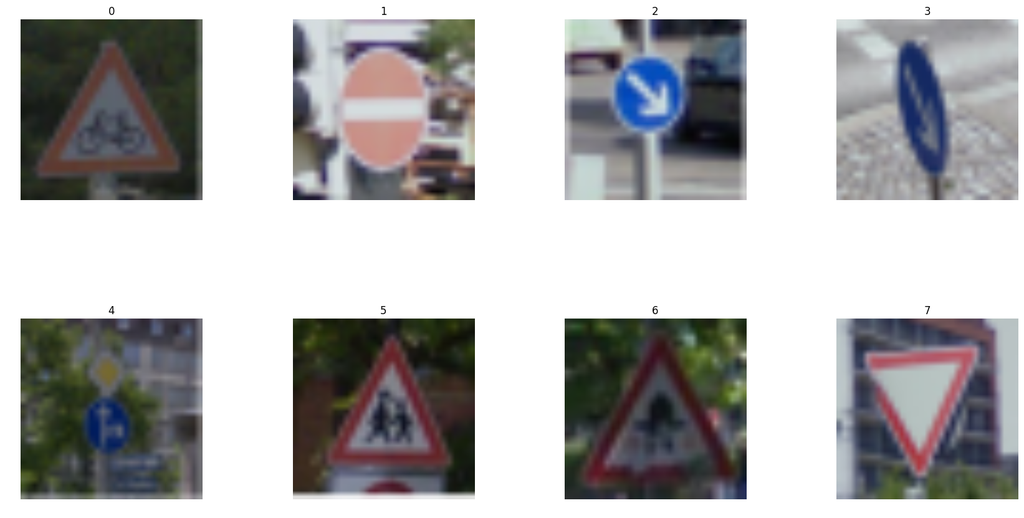

```python
### Load the images and plot them here.
### Feel free to use as many code cells as needed.
import numpy as np
import matplotlib.pyplot as plt
import matplotlib.image as mpimg
import cv2

#Read sample images from extra folder
file_name = './google-stree-view-munich/file'
num_files = 8

img_list  = []
for i in range(num_files):
    full_path = file_name + str(i) + '.png'
    img = mpimg.imread(full_path)
    #Interestingly, using cubic, liner, lancos approch of interpoloation were producing very pixelated results
    resize_img = cv2.resize(img, (32, 32), interpolation=cv2.INTER_AREA)
    img_list.append(resize_img)

munich_set = np.array(img_list)

print('Google Street view - Munich...')
plotImages(munich_set, np.arange(num_files))
```

```
Stree signs - India...
```

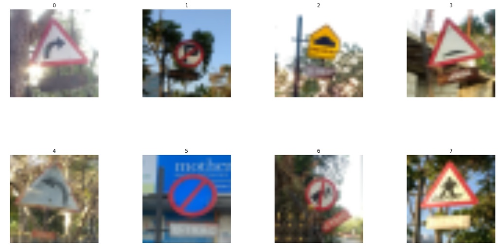

```python
### Load the images and plot them here.
### Feel free to use as many code cells as needed.
import numpy as np
import matplotlib.pyplot as plt
import matplotlib.image as mpimg
import cv2

#Read sample images from extra folder
file_name = './traffic-signs-india/file'
num_files = 8

img_list  = []
for i in range(num_files):
    full_path = file_name + str(i) + '.jpeg'
    img = mpimg.imread(full_path)
    #Interestingly, using cubic, liner, lancos approch of interpoloation were producing very pixelated results
    resize_img = cv2.resize(img, (32, 32), interpolation=cv2.INTER_AREA)
    img_list.append(resize_img)

india_set = np.array(img_list)

print('Stree signs - India...')
plotImages(india_set, np.arange(num_files))
```

### Question 6

*Choose five candidate images of traffic signs and provide them in the report. Are there any particular qualities of the image(s) that might make classification difficult? It could be helpful to plot the images in the notebook.*

**Answer:**

The additional 8 German Traffic signs shown above were taken from Google's street view of Munich city. Out of the 8 traffic signs images 3 and 4 in particular will be difficult to classify.

Image 3 has an affine transformation (translation and rotation) and also some amount to zoom to it. The classifier is not trained with these image distrotions to might entirely misclassify the sign.

Image 4 has two signs in it, one on top of another. The classifier is trained to take on just one traffic sign per image so it might get confused as to which one to predict. It might even entirely miss predict both as a completely different sign altogether.

The images in Traffic sign - India set were taken on the streets of Bangalore! :) They differ to a large extent with German traffic signs, but basic shapes are similar such as triangular for warning signs, circular for speed signs, etc...

```python
### Run the predictions here.
### Feel free to use as many code cells as needed.
saver = tf.train.Saver()

samples = 8
print("Running ...")

munich_in = []
india_in = []
with tf.Session() as sess:
    ckpt = tf.train.get_checkpoint_state('.')
    if ckpt and ckpt.model_checkpoint_path:
        # Restores from checkpointprint(images)

        print ('Model found!')
        saver.restore(sess, ckpt.model_checkpoint_path)
        print ('Model loaded!')
    else:
        print ('No checkpoint file found!')

    for i in range(samples):
        munich_in.append(sess.run(tf.image.resize_image_with_crop_or_pad(munich_set[i], 30, 30)))
        india_in.append(sess.run(tf.image.resize_image_with_crop_or_pad(india_set[i], 30, 30)))

    logits_munich = sess.run(logits, feed_dict={x:munich_in, keep_prob: 1.0})
    logits_india = sess.run(logits, feed_dict={x:india_in, keep_prob: 1.0})

    sess.close()

print('Logits ready!')
```

```
Running ...
Model found!
Model loaded!
Logits ready!
```

### Question 7

*Is your model able to perform equally well on captured pictures when compared to testing on the dataset? The simplest way to do this check the accuracy of the predictions. For example, if the model predicted 1 out of 5 signs correctly, it's 20% accurate.*

**NOTE:** You could check the accuracy manually by using `signnames.csv` (same directory). This file has a mapping from the class id (0-42) to the corresponding sign name. So, you could take the class id the model outputs, lookup the name in `signnames.csv` and see if it matches the sign from the image.

```python
#Get a handle to Saver() to resotre the trainied model
saver = tf.train.Saver()

test_itrs = len(test_set)
print("Running Test set...")

img_list  = []
for i in range(test_itrs):
    img = X_test[i]
    resize_img = cv2.resize(img, (30, 30), interpolation=cv2.INTER_CUBIC)
    img_list.append(resize_img)

test_set = np.array(img_list)

y_pred = tf.argmax(logits, 1)

with tf.Session() as sess:
    ckpt = tf.train.get_checkpoint_state('.')
    if ckpt and ckpt.model_checkpoint_path:
        # Restores from checkpoint
        print ('Model found!')
        saver.restore(sess, ckpt.model_checkpoint_path)
        print ('Model loaded!')
    else:
        print ('No checkpoint file found!')

    test_pred = sess.run(y_pred, feed_dict={x:test_set, y:y_test, keep_prob: 1.0})

print('Test predicitons ready!')
```

```
Running Test set...
Model found!
Model loaded!
Test predicitons ready!
```

Compute the precison and recall of each class and visualize which classes needs more data augmentation.

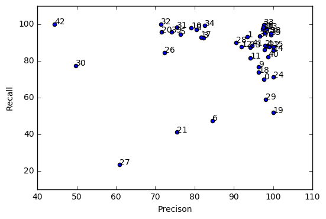

```python
import sklearn as sk
from astropy.table import Table

precision = sk.metrics.precision_score(y_test, test_pred, average=None) * 100.
recall = sk.metrics.recall_score(y_test, test_pred, average=None) * 100.
plotScatter(precision, recall, np.arange(n_classes), 'Precison', 'Recall')
```

**Answer:**

It is not possible to improve the accuracy of a classifier by just relying on average precision, or just with a few sample images. Its good to know the precision and recall of each class in the test set to truly know the performance of a classifier.

From the scatter plot, it can be seen that several classes have high precision and recall percentage.

Classes (29, 19) have a recall of less than 60% even though precision is 100%

Classes (6, 21) have a recall of less than 50% with lower precision (75% to 85%)

Class (30) has precision of 50% but a recall of (80%)

Class (27) is the class with lowest recall (25%) and low precision (60%)

Data augmentation techniques such as affine transformations (rotation, scaling), random scaling, noise injection, etc. will help improve both recall and precision of all the classes.

### Question 8

*Use the model's softmax probabilities to visualize the **certainty** of its predictions, [`tf.nn.top_k`](https://www.tensorflow.org/versions/r0.12/api_docs/python/nn.html#top_k) could prove helpful here. Which predictions is the model certain of? Uncertain? If the model was incorrect in its initial prediction, does the correct prediction appear in the top k? (k should be 5 at most)*

`tf.nn.top_k` will return the values and indices (class ids) of the top k predictions. So if k=3, for each sign, it'll return the 3 largest probabilities (out of a possible 43) and the correspoding class ids.

Take this numpy array as an example:

```
# (5, 6) array
a = np.array([[ 0.24879643,  0.07032244,  0.12641572,  0.34763842,  0.07893497,
         0.12789202],
       [ 0.28086119,  0.27569815,  0.08594638,  0.0178669 ,  0.18063401,
         0.15899337],
       [ 0.26076848,  0.23664738,  0.08020603,  0.07001922,  0.1134371 ,
         0.23892179],
       [ 0.11943333,  0.29198961,  0.02605103,  0.26234032,  0.1351348 ,
         0.16505091],
       [ 0.09561176,  0.34396535,  0.0643941 ,  0.16240774,  0.24206137,
         0.09155967]])
```

Running it through `sess.run(tf.nn.top_k(tf.constant(a), k=3))` produces:

```
TopKV2(values=array([[ 0.34763842,  0.24879643,  0.12789202],
       [ 0.28086119,  0.27569815,  0.18063401],
       [ 0.26076848,  0.23892179,  0.23664738],
       [ 0.29198961,  0.26234032,  0.16505091],
       [ 0.34396535,  0.24206137,  0.16240774]]), indices=array([[3, 0, 5],
       [0, 1, 4],
       [0, 5, 1],
       [1, 3, 5],
       [1, 4, 3]], dtype=int32))
```

Looking just at the first row we get `[ 0.34763842, 0.24879643, 0.12789202]`, you can confirm these are the 3 largest probabilities in `a`. You'll also notice `[3, 0, 5]` are the corresponding indices.

```
Munich set results...
```

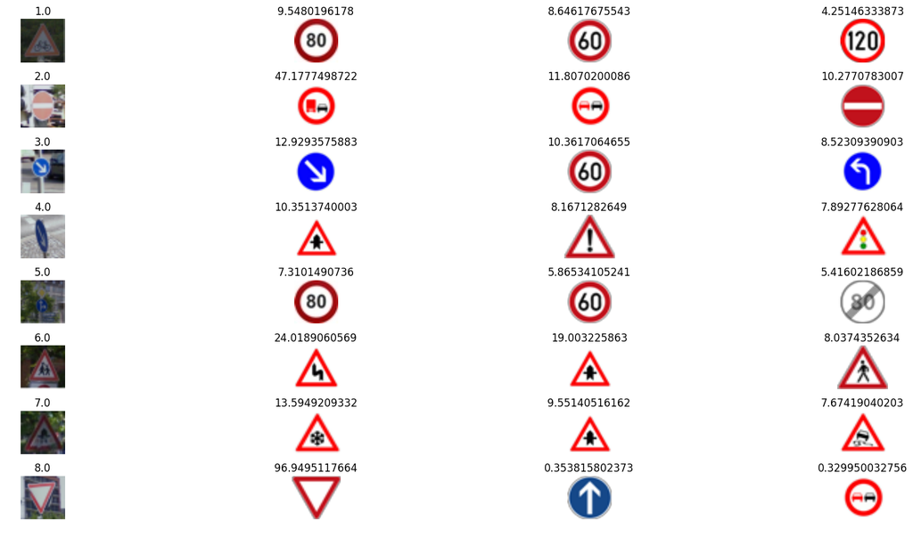

```python
### Visualize the softmax probabilities here.
### Feel free to use as many code cells as needed.

top_prob = 3
with tf.Session() as sess:

    for i in range(samples):
        test_softmax = tf.nn.softmax(logits_munich)

    test_softmax_arr = sess.run(test_softmax)

    top_values, top_indices = sess.run(tf.nn.top_k(tf.constant(test_softmax_arr), k=top_prob))
    sess.close()

show_list = []
accuracy_list = []

#Reorganize the plot to diplay inputs and refrence icons
for i in range(samples):
    show_list.append(munich_set[i])
    accuracy_list.append(i + 1)
    for k in range(top_prob):
        index = top_indices[i][k]
        show_list.append(icon_set[index])
        accuracy_list.append(top_values[i][k] * 100.)

res_arr = np.array(show_list)
accuracy_arr = np.array(accuracy_list)
print('Munich set results...')
plotImages(res_arr, accuracy_arr)
```

Image 4.0 will be difficult to classify as there is an affine warp to the image from the angle it was captured. Image 5.0 will be again difficult as it has two traffic signs one on top of each other.

```
India set results...
```

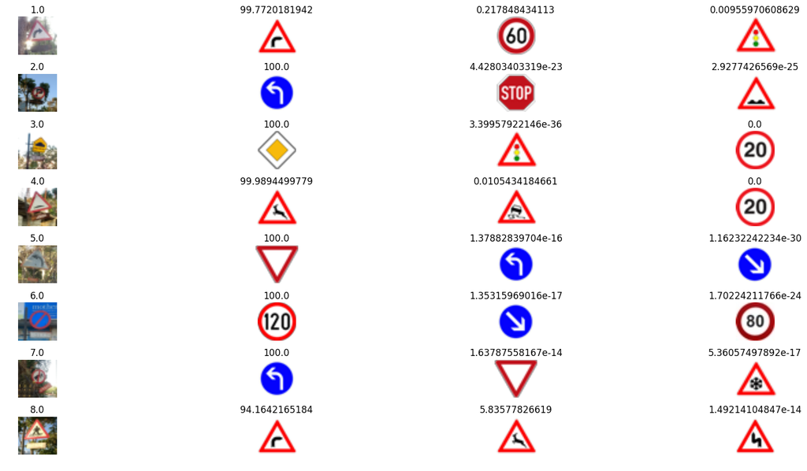

```python
top_prob = 3
show_list = []
accuracy_list = []

with tf.Session() as sess:

    for i in range(samples):
        extra_softmax = tf.nn.softmax(logits_india)

    extra_softmax_arr = sess.run(extra_softmax)

    top_values, top_indices = sess.run(tf.nn.top_k(tf.constant(extra_softmax_arr), k=top_prob))
    sess.close()

#Reorganize the plot to diplay inputs and refrence icons
for i in range(samples):
    show_list.append(india_set[i])
    accuracy_list.append(i+1)
    for k in range(top_prob):
        index = top_indices[i][k]
        show_list.append(icon_set[index])
        accuracy_list.append(top_values[i][k] * 100.)

res_arr = np.array(show_list)
accuracy_arr = np.array(accuracy_list)
print('India set results...')
plotImages(res_arr, accuracy_arr)
```

**Answer:**

The model tries to output signs matching closer to the shape, color etc. As traffic signs in India is very different from the German traffic signs, classification accuracy is a hit or miss.

Image 1.0 which indicates turn right with caution (India) has a 99.77 % match with a dangerous turn right (Germany). Which is good!

Image 2.0 which indicates no parking (India) strangely and confidently picks up with 100% match for "turn left ahead" which is kinda strange. Although there is no similar traffic sign in the given data set, I would have expected to have picked up anything other than all blue traffic sign. Suprising thing is its 100% accurate.

Image 3.0 which indicates speed hump (India) matches with 100% confidence with priority road (Germany). This I feel it has picked up based on similar yellow color. Which seems intiutively right as there is no matching sign in the given set.

Image 5.0 which indicates turn left with caution (India) has 100% match with yield sign (Germany). Although the shape is inverted it has picked up something similar. The 2nd guess "turn left ahead" (Germany) also has a faint probabilty which is good.

Image 8.0 which indicates pedestrian walk way (India) has good match with triangular shaped traffic signes (Germany) although a match with Pedestrian (Germany) would have indicated that network is not overfit to that particular symbol